# CS5014 Machine Learning

$x^{T}Ax$ Quadratic form

Lei Fang

01/02/2021

# Introduction

A quadratic form is defined as
$$x^TAx,$$
where $x=\begin{bmatrix} x_1 \\x^2\\ \vdots\\x^n \end{bmatrix}$ is a $n\times 1$ (column) vector, $A$ is a $n\times n$ square matrix (the corresponding $i$-th row and $j$-th column entry is $a_{ij}$. Therefore, $x^TAx$ is scalar function of input $x$. According to matrix multiplication rule, the quadratic form can be expanded as
$$x^TAx = \sum_{i=1}^n \sum_{j=1}^n a_{ij}x_ix_j$$
essentially all the second order products between $x_ix_j$ and weighed by $a_{ij}$.

\begin{example} $f(x) = x_1^2 + x_2^2$ is a quadratic form, where $x=[x_1, x_2]^T$ and $I=\begin{bmatrix} 1,0\\0,1\end{bmatrix}$. so $f(x) = x^TIx = x^Tx$. Its surface plot in $R^3$ is

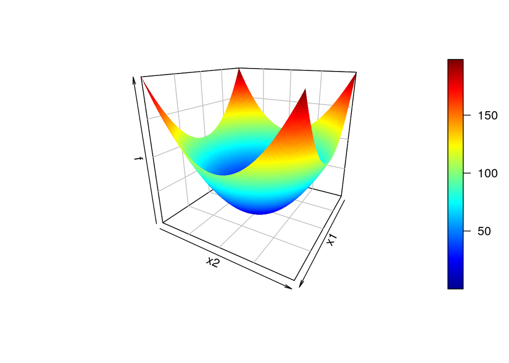

Quadatric form, $x^{T}Ax$, is used a lot in machine learning models. The following are three cases that quadratic forms are used.

the loss function of a linear regression is
$$L(\theta) = (y-X\theta)^T(y-X\theta),$$
which is a quadratic form of $\theta$.

the kernel of a multivariate Gaussian is a quadratic form, namely
$$-\frac{1}{2}(x-\mu)^T\Sigma^{-1}(x-\mu),$$
where $\mu, \Sigma$ are the mean and variance-covariance matrix respectively. The kernel is a quadratic form of input $x$.

Taylor’s expansion contains quadratic forms as well:
$$T(x) = f(a) + \nabla_x f(a)(x-a) + \frac{1}{2!} (x-a)^{T}\nabla^2_xf(a)(x-a)+\ldots,$$
where $\nabla_x f(a)$ is the gradient of $f$ and $\nabla^2_x f(a)$ is the hessian matrix. Note that we define gradients as row vectors, so the second term $\nabla_x f(a)(x-a)$ is an inner product. The expansion approximates a multivariate $R^n\rightarrow R$ function $f(x)$ with a polynomial function $T(x)$. The third term is a quadratic form of input $x$.

## Positive definite quadratic form

a multivaraite Gaussian distribution ($k$ dimensional) is
$$p(x) = (2\pi)^{-\frac{k}{2}} \text{det}(\Sigma)^{-\frac{1}{2}} e^{-\frac{1}{2} (x-\mu)^T\Sigma^{-1}(x-\mu)}$$

This note lists some important facts about quadratic form.

First and foremost, it returns a scalar given an input of vector $x$.

$$x^TAx: R^{m}\rightarrow R$$